# Risk Factor Analysis

## Outcome Variable

**Outcome Variable:** wasted

## Predictor Variables

**Intervention Variable:** nchldlt5

**Adjustment Set:**

unadjusted

## Stratifying Variables

The analysis was stratified on these variable(s):

- agecat
- studyid
- country

## Data Summary

| agecat | studyid | country | nchldlt5 | wasted | n_cell | n |
| --- | --- | --- | --- | --- | --- | --- |
| Birth | ki1000108-IRC | INDIA | 1 | 0 | 50 | 245 |
| Birth | ki1000108-IRC | INDIA | 1 | 1 | 22 | 245 |
| Birth | ki1000108-IRC | INDIA | 2+ | 0 | 129 | 245 |
| Birth | ki1000108-IRC | INDIA | 2+ | 1 | 44 | 245 |
| Birth | ki1017093c-NIH-Crypto | BANGLADESH | 1 | 0 | 12 | 16 |
| Birth | ki1017093c-NIH-Crypto | BANGLADESH | 1 | 1 | 3 | 16 |
| Birth | ki1017093c-NIH-Crypto | BANGLADESH | 2+ | 0 | 1 | 16 |
| Birth | ki1017093c-NIH-Crypto | BANGLADESH | 2+ | 1 | 0 | 16 |
| Birth | kiGH5241-JiVitA-3 | BANGLADESH | 1 | 0 | 16820 | 19544 |
| Birth | kiGH5241-JiVitA-3 | BANGLADESH | 1 | 1 | 1948 | 19544 |
| Birth | kiGH5241-JiVitA-3 | BANGLADESH | 2+ | 0 | 730 | 19544 |
| Birth | kiGH5241-JiVitA-3 | BANGLADESH | 2+ | 1 | 46 | 19544 |
| 6 months | ki1000108-IRC | INDIA | 1 | 0 | 77 | 289 |
| 6 months | ki1000108-IRC | INDIA | 1 | 1 | 11 | 289 |
| 6 months | ki1000108-IRC | INDIA | 2+ | 0 | 174 | 289 |
| 6 months | ki1000108-IRC | INDIA | 2+ | 1 | 27 | 289 |
| 6 months | ki1017093b-PROVIDE | BANGLADESH | 1 | 0 | 409 | 435 |
| 6 months | ki1017093b-PROVIDE | BANGLADESH | 1 | 1 | 17 | 435 |
| 6 months | ki1017093b-PROVIDE | BANGLADESH | 2+ | 0 | 8 | 435 |
| 6 months | ki1017093b-PROVIDE | BANGLADESH | 2+ | 1 | 1 | 435 |
| 6 months | ki1017093c-NIH-Crypto | BANGLADESH | 1 | 0 | 494 | 512 |
| 6 months | ki1017093c-NIH-Crypto | BANGLADESH | 1 | 1 | 13 | 512 |
| 6 months | ki1017093c-NIH-Crypto | BANGLADESH | 2+ | 0 | 5 | 512 |
| 6 months | ki1017093c-NIH-Crypto | BANGLADESH | 2+ | 1 | 0 | 512 |
| 6 months | ki1066203-TanzaniaChild2 | TANZANIA, UNITED REPUBLIC OF | 1 | 0 | 1335 | 1452 |
| 6 months | ki1066203-TanzaniaChild2 | TANZANIA, UNITED REPUBLIC OF | 1 | 1 | 55 | 1452 |
| 6 months | ki1066203-TanzaniaChild2 | TANZANIA, UNITED REPUBLIC OF | 2+ | 0 | 56 | 1452 |
| 6 months | ki1066203-TanzaniaChild2 | TANZANIA, UNITED REPUBLIC OF | 2+ | 1 | 6 | 1452 |
| 6 months | ki1148112-LCNI-5 | MALAWI | 1 | 0 | 384 | 453 |
| 6 months | ki1148112-LCNI-5 | MALAWI | 1 | 1 | 6 | 453 |
| 6 months | ki1148112-LCNI-5 | MALAWI | 2+ | 0 | 63 | 453 |
| 6 months | ki1148112-LCNI-5 | MALAWI | 2+ | 1 | 0 | 453 |
| 6 months | kiGH5241-JiVitA-3 | BANGLADESH | 1 | 0 | 19916 | 22430 |
| 6 months | kiGH5241-JiVitA-3 | BANGLADESH | 1 | 1 | 1791 | 22430 |
| 6 months | kiGH5241-JiVitA-3 | BANGLADESH | 2+ | 0 | 639 | 22430 |
| 6 months | kiGH5241-JiVitA-3 | BANGLADESH | 2+ | 1 | 84 | 22430 |
| 24 months | ki1000108-IRC | INDIA | 1 | 0 | 78 | 290 |
| 24 months | ki1000108-IRC | INDIA | 1 | 1 | 11 | 290 |
| 24 months | ki1000108-IRC | INDIA | 2+ | 0 | 184 | 290 |
| 24 months | ki1000108-IRC | INDIA | 2+ | 1 | 17 | 290 |
| 24 months | ki1017093b-PROVIDE | BANGLADESH | 1 | 0 | 375 | 431 |
| 24 months | ki1017093b-PROVIDE | BANGLADESH | 1 | 1 | 48 | 431 |
| 24 months | ki1017093b-PROVIDE | BANGLADESH | 2+ | 0 | 6 | 431 |
| 24 months | ki1017093b-PROVIDE | BANGLADESH | 2+ | 1 | 2 | 431 |
| 24 months | ki1017093c-NIH-Crypto | BANGLADESH | 1 | 0 | 328 | 361 |
| 24 months | ki1017093c-NIH-Crypto | BANGLADESH | 1 | 1 | 29 | 361 |
| 24 months | ki1017093c-NIH-Crypto | BANGLADESH | 2+ | 0 | 4 | 361 |
| 24 months | ki1017093c-NIH-Crypto | BANGLADESH | 2+ | 1 | 0 | 361 |
| 24 months | ki1066203-TanzaniaChild2 | TANZANIA, UNITED REPUBLIC OF | 1 | 0 | 5 | 5 |
| 24 months | ki1066203-TanzaniaChild2 | TANZANIA, UNITED REPUBLIC OF | 1 | 1 | 0 | 5 |
| 24 months | ki1066203-TanzaniaChild2 | TANZANIA, UNITED REPUBLIC OF | 2+ | 0 | 0 | 5 |
| 24 months | ki1066203-TanzaniaChild2 | TANZANIA, UNITED REPUBLIC OF | 2+ | 1 | 0 | 5 |
| 24 months | ki1148112-LCNI-5 | MALAWI | 1 | 0 | 271 | 321 |
| 24 months | ki1148112-LCNI-5 | MALAWI | 1 | 1 | 6 | 321 |
| 24 months | ki1148112-LCNI-5 | MALAWI | 2+ | 0 | 42 | 321 |
| 24 months | ki1148112-LCNI-5 | MALAWI | 2+ | 1 | 2 | 321 |
| 24 months | kiGH5241-JiVitA-3 | BANGLADESH | 1 | 0 | 8383 | 11282 |
| 24 months | kiGH5241-JiVitA-3 | BANGLADESH | 1 | 1 | 2460 | 11282 |
| 24 months | kiGH5241-JiVitA-3 | BANGLADESH | 2+ | 0 | 345 | 11282 |
| 24 months | kiGH5241-JiVitA-3 | BANGLADESH | 2+ | 1 | 94 | 11282 |

The following strata were considered:

- agecat: 24 months, studyid: ki1000108-IRC, country: INDIA
- agecat: 24 months, studyid: ki1017093b-PROVIDE, country: BANGLADESH
- agecat: 24 months, studyid: ki1017093c-NIH-Crypto, country: BANGLADESH
- agecat: 24 months, studyid: ki1066203-TanzaniaChild2, country: TANZANIA, UNITED REPUBLIC OF
- agecat: 24 months, studyid: ki1148112-LCNI-5, country: MALAWI
- agecat: 24 months, studyid: kiGH5241-JiVitA-3, country: BANGLADESH
- agecat: 6 months, studyid: ki1000108-IRC, country: INDIA
- agecat: 6 months, studyid: ki1017093b-PROVIDE, country: BANGLADESH
- agecat: 6 months, studyid: ki1017093c-NIH-Crypto, country: BANGLADESH
- agecat: 6 months, studyid: ki1066203-TanzaniaChild2, country: TANZANIA, UNITED REPUBLIC OF
- agecat: 6 months, studyid: ki1148112-LCNI-5, country: MALAWI
- agecat: 6 months, studyid: kiGH5241-JiVitA-3, country: BANGLADESH
- agecat: Birth, studyid: ki1000108-IRC, country: INDIA
- agecat: Birth, studyid: ki1017093c-NIH-Crypto, country: BANGLADESH
- agecat: Birth, studyid: kiGH5241-JiVitA-3, country: BANGLADESH

### Dropped Strata

Some strata were dropped due to rare outcomes:

- agecat: Birth, studyid: ki1017093c-NIH-Crypto, country: BANGLADESH
- agecat: 6 months, studyid: ki1017093b-PROVIDE, country: BANGLADESH
- agecat: 6 months, studyid: ki1017093c-NIH-Crypto, country: BANGLADESH
- agecat: 6 months, studyid: ki1148112-LCNI-5, country: MALAWI
- agecat: 24 months, studyid: ki1017093b-PROVIDE, country: BANGLADESH
- agecat: 24 months, studyid: ki1017093c-NIH-Crypto, country: BANGLADESH
- agecat: 24 months, studyid: ki1066203-TanzaniaChild2, country: TANZANIA, UNITED REPUBLIC OF
- agecat: 24 months, studyid: ki1148112-LCNI-5, country: MALAWI

## Methods Detail

We’re interested in the causal parameters $E[Y_a]$ for all values of $a \in \mathcal{A}$. These parameters represent the mean outcome if, possibly contrary to fact, we intervened to set all units to have $A=a$. Under the randomization and positivity assumptions, these are identified by the statistical parameters $\psi_a=E_W[E_{Y|A,W}(Y|A=a,W)]$. In addition, we’re interested in the mean of $Y$, $E[Y]$ under no intervention (the observed mean). We will estimate these parameters by using SuperLearner to fit the relevant likelihood factors – $E_{Y|A,W}(Y|A=a,W)$ and $p(A=a|W)$, and then updating our likelihood fit using a joint TMLE.

For unadjusted analyses ($W=\{\}$), initial likelihoods were estimated using Lrnr_glm to estimate the simple $E(Y|A)$ and Lrnr_mean to estimate $p(A)$. For adjusted analyses, a small library containing Lrnr_glmnet, Lrnr_xgboost, and Lrnr_mean was used.

Having estimated these parameters, we will then use the delta method to estimate relative risks and attributable risks relative to a prespecified baseline level of $A$.

# Results Detail

## Results Plots

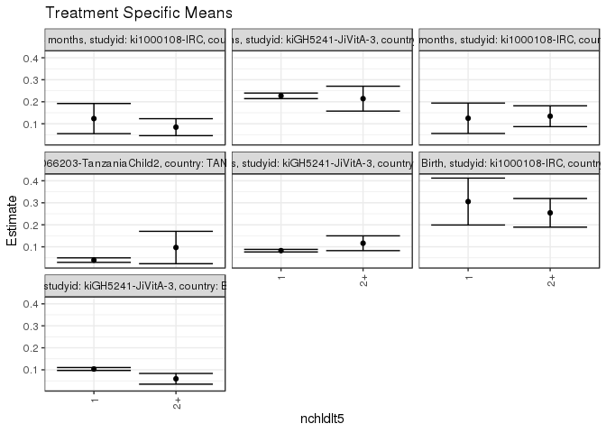

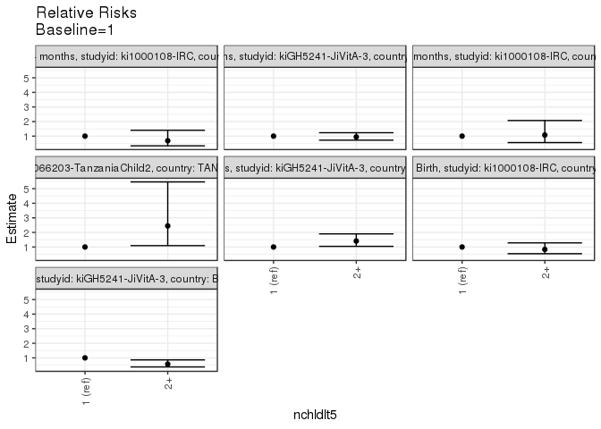

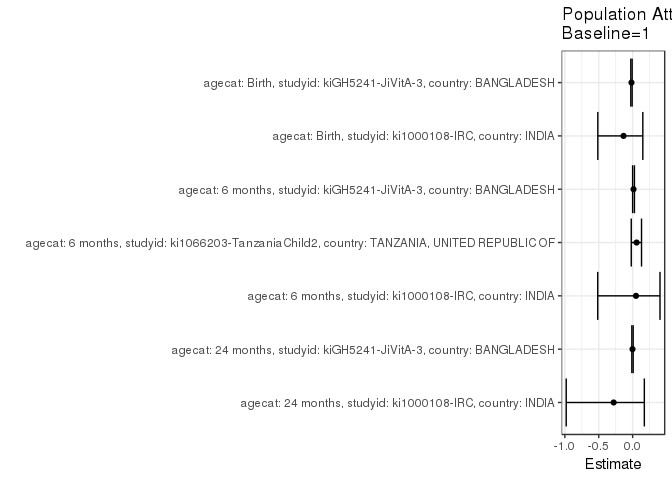

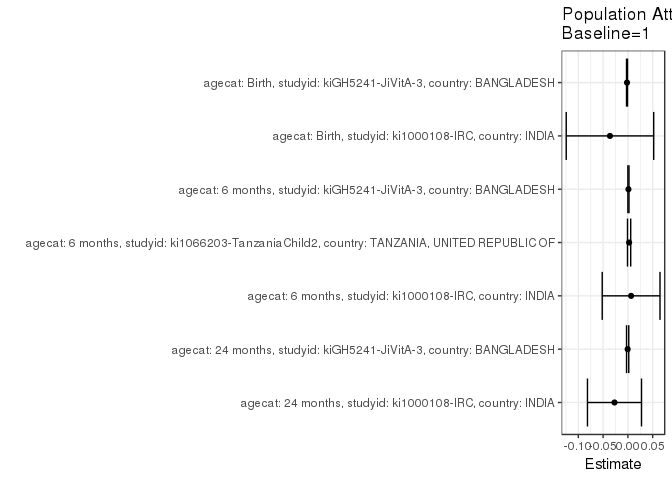

## Results Table

### Parameter: TSM

| agecat | studyid | country | intervention_level | baseline_level | estimate | ci_lower | ci_upper |
| --- | --- | --- | --- | --- | --- | --- | --- |
| Birth | ki1000108-IRC | INDIA | 1 | NA | 0.3055556 | 0.1989367 | 0.4121744 |
| Birth | ki1000108-IRC | INDIA | 2+ | NA | 0.2543353 | 0.1893091 | 0.3193614 |
| Birth | kiGH5241-JiVitA-3 | BANGLADESH | 1 | NA | 0.1037937 | 0.0971446 | 0.1104428 |
| Birth | kiGH5241-JiVitA-3 | BANGLADESH | 2+ | NA | 0.0592784 | 0.0348562 | 0.0837005 |
| 6 months | ki1000108-IRC | INDIA | 1 | NA | 0.1250000 | 0.0557821 | 0.1942179 |
| 6 months | ki1000108-IRC | INDIA | 2+ | NA | 0.1343284 | 0.0871043 | 0.1815524 |
| 6 months | ki1066203-TanzaniaChild2 | TANZANIA, UNITED REPUBLIC OF | 1 | NA | 0.0395683 | 0.0293166 | 0.0498201 |
| 6 months | ki1066203-TanzaniaChild2 | TANZANIA, UNITED REPUBLIC OF | 2+ | NA | 0.0967742 | 0.0231569 | 0.1703915 |
| 6 months | kiGH5241-JiVitA-3 | BANGLADESH | 1 | NA | 0.0825079 | 0.0766119 | 0.0884040 |
| 6 months | kiGH5241-JiVitA-3 | BANGLADESH | 2+ | NA | 0.1161826 | 0.0825256 | 0.1498396 |
| 24 months | ki1000108-IRC | INDIA | 1 | NA | 0.1235955 | 0.0551008 | 0.1920902 |
| 24 months | ki1000108-IRC | INDIA | 2+ | NA | 0.0845771 | 0.0460437 | 0.1231105 |
| 24 months | kiGH5241-JiVitA-3 | BANGLADESH | 1 | NA | 0.2268745 | 0.2142693 | 0.2394797 |
| 24 months | kiGH5241-JiVitA-3 | BANGLADESH | 2+ | NA | 0.2141230 | 0.1575238 | 0.2707222 |

### Parameter: E(Y)

| agecat | studyid | country | intervention_level | baseline_level | estimate | ci_lower | ci_upper |
| --- | --- | --- | --- | --- | --- | --- | --- |
| Birth | ki1000108-IRC | INDIA | NA | NA | 0.2693878 | 0.2137223 | 0.3250532 |
| Birth | kiGH5241-JiVitA-3 | BANGLADESH | NA | NA | 0.1020262 | 0.0954832 | 0.1085692 |
| 6 months | ki1000108-IRC | INDIA | NA | NA | 0.1314879 | 0.0924593 | 0.1705165 |
| 6 months | ki1066203-TanzaniaChild2 | TANZANIA, UNITED REPUBLIC OF | NA | NA | 0.0420110 | 0.0316887 | 0.0523333 |
| 6 months | kiGH5241-JiVitA-3 | BANGLADESH | NA | NA | 0.0835934 | 0.0778034 | 0.0893834 |
| 24 months | ki1000108-IRC | INDIA | NA | NA | 0.0965517 | 0.0625006 | 0.1306028 |
| 24 months | kiGH5241-JiVitA-3 | BANGLADESH | NA | NA | 0.2263783 | 0.2139633 | 0.2387933 |

### Parameter: RR

| agecat | studyid | country | intervention_level | baseline_level | estimate | ci_lower | ci_upper |
| --- | --- | --- | --- | --- | --- | --- | --- |
| Birth | ki1000108-IRC | INDIA | 1 | 1 | 1.0000000 | 1.0000000 | 1.0000000 |
| Birth | ki1000108-IRC | INDIA | 2+ | 1 | 0.8323699 | 0.5400707 | 1.2828686 |
| Birth | kiGH5241-JiVitA-3 | BANGLADESH | 1 | 1 | 1.0000000 | 1.0000000 | 1.0000000 |
| Birth | kiGH5241-JiVitA-3 | BANGLADESH | 2+ | 1 | 0.5711171 | 0.3783300 | 0.8621433 |
| 6 months | ki1000108-IRC | INDIA | 1 | 1 | 1.0000000 | 1.0000000 | 1.0000000 |
| 6 months | ki1000108-IRC | INDIA | 2+ | 1 | 1.0746269 | 0.5576962 | 2.0707026 |
| 6 months | ki1066203-TanzaniaChild2 | TANZANIA, UNITED REPUBLIC OF | 1 | 1 | 1.0000000 | 1.0000000 | 1.0000000 |
| 6 months | ki1066203-TanzaniaChild2 | TANZANIA, UNITED REPUBLIC OF | 2+ | 1 | 2.4457478 | 1.0949710 | 5.4628681 |
| 6 months | kiGH5241-JiVitA-3 | BANGLADESH | 1 | 1 | 1.0000000 | 1.0000000 | 1.0000000 |
| 6 months | kiGH5241-JiVitA-3 | BANGLADESH | 2+ | 1 | 1.4081380 | 1.0441082 | 1.8990872 |
| 24 months | ki1000108-IRC | INDIA | 1 | 1 | 1.0000000 | 1.0000000 | 1.0000000 |
| 24 months | ki1000108-IRC | INDIA | 2+ | 1 | 0.6843057 | 0.3339476 | 1.4022388 |
| 24 months | kiGH5241-JiVitA-3 | BANGLADESH | 1 | 1 | 1.0000000 | 1.0000000 | 1.0000000 |
| 24 months | kiGH5241-JiVitA-3 | BANGLADESH | 2+ | 1 | 0.9437950 | 0.7222991 | 1.2332135 |

### Parameter: PAR

| agecat | studyid | country | intervention_level | baseline_level | estimate | ci_lower | ci_upper |
| --- | --- | --- | --- | --- | --- | --- | --- |
| Birth | ki1000108-IRC | INDIA | 1 | NA | -0.0361678 | -0.1243997 | 0.0520641 |
| Birth | kiGH5241-JiVitA-3 | BANGLADESH | 1 | NA | -0.0017675 | -0.0027704 | -0.0007646 |
| 6 months | ki1000108-IRC | INDIA | 1 | NA | 0.0064879 | -0.0517922 | 0.0647680 |
| 6 months | ki1066203-TanzaniaChild2 | TANZANIA, UNITED REPUBLIC OF | 1 | NA | 0.0024427 | -0.0007864 | 0.0056718 |
| 6 months | kiGH5241-JiVitA-3 | BANGLADESH | 1 | NA | 0.0010855 | -0.0000251 | 0.0021960 |
| 24 months | ki1000108-IRC | INDIA | 1 | NA | -0.0270438 | -0.0815541 | 0.0274665 |
| 24 months | kiGH5241-JiVitA-3 | BANGLADESH | 1 | NA | -0.0004962 | -0.0027300 | 0.0017377 |

### Parameter: PAF

| agecat | studyid | country | intervention_level | baseline_level | estimate | ci_lower | ci_upper |
| --- | --- | --- | --- | --- | --- | --- | --- |
| Birth | ki1000108-IRC | INDIA | 1 | NA | -0.1342593 | -0.5137184 | 0.1500770 |
| Birth | kiGH5241-JiVitA-3 | BANGLADESH | 1 | NA | -0.0173239 | -0.0272312 | -0.0075122 |
| 6 months | ki1000108-IRC | INDIA | 1 | NA | 0.0493421 | -0.5150656 | 0.4034909 |
| 6 months | ki1066203-TanzaniaChild2 | TANZANIA, UNITED REPUBLIC OF | 1 | NA | 0.0581436 | -0.0206111 | 0.1308214 |
| 6 months | kiGH5241-JiVitA-3 | BANGLADESH | 1 | NA | 0.0129849 | -0.0004211 | 0.0262113 |
| 24 months | ki1000108-IRC | INDIA | 1 | NA | -0.2800963 | -0.9798911 | 0.1723552 |
| 24 months | kiGH5241-JiVitA-3 | BANGLADESH | 1 | NA | -0.0021918 | -0.0121096 | 0.0076288 |